# STAT 534: Homework 3

Erick Calderon-Morales

Fall 2021

```r
library(leaps)
library(tidyverse)
library(glmnet)
library(janitor)
library(MASS)
library(ISLR)
library(NHANES)
library(broom)
library(rsample)
library(caret)
```

# Exercise 1

**In this problem, we will generate simulated data, and will then use this data to perform variable selection.**

**(a) Use the rnorm() function to generate a predictor X of length n = 100, as well as a noise vector $\epsilon$ of the same length. Then generate a response vector Y according to the model:**

$$Y = β_0 + β_1 X + β_2X^2 + β_3X^3 + \epsilon$$
**where $\beta_0$,…, $\beta_3$ are constants of your choice.**

```r
x <- rnorm(100)
e <- rnorm(100)
```

```r
y <- 9 + 1 * x + 2 * x^2 - 3 * x^3 + e
```

**(b) Given the predictors $X$, $X^2$ , …, $X^{10}$ , perform best subset selection in order to choose the best model. What is the best model obtained according to Cp, AIC, BIC and adjusted $R^2$ ? Show some plots to provide evidence for your answer, and report the coefficients of the best model obtained.**

```r
# Get AIC values
poly_degree <- seq(1, 10)

# Empty vector
aic <- double(length(poly_degree))

for (each_value in seq(along = poly_degree)) {
 k <- poly_degree[each_value]

 # Polynomial Model
 aic_out <- lm(y ~ poly(x, k))

 # Assing it to vector
 aic[each_value] <- AIC(aic_out)
}

aic_values <- cbind(poly_degree,aic)
```

```r
data_from_linear_model <- data.frame(y,x)

# Generate polinomial regression up to 10
fit <- regsubsets(y ~ poly(x, 10), data = data_from_linear_model, nvmax = 10)
fit_summary <- summary(fit)
```

```r
# Choose best model
data.frame(
  r2 = which.max(fit_summary$adjr2),
  cp = which.min(fit_summary$cp),
  BIC = which.min(fit_summary$bic),
  aic = which.min(aic_values[,2])
)
```

```
  r2 cp BIC aic
1  5  3   3   3
```

```r
# Generate data frame with metrics

data_model_selection <-
  data_frame(cp = fit_summary$cp,
           BIC = fit_summary$bic,
           r2 = fit_summary$adjr2) %>%

    # add aic values
    cbind(., aic_values[,2]) %>%
    rename(AIC = "aic_values[, 2]") %>%

    mutate(id = row_number())
```

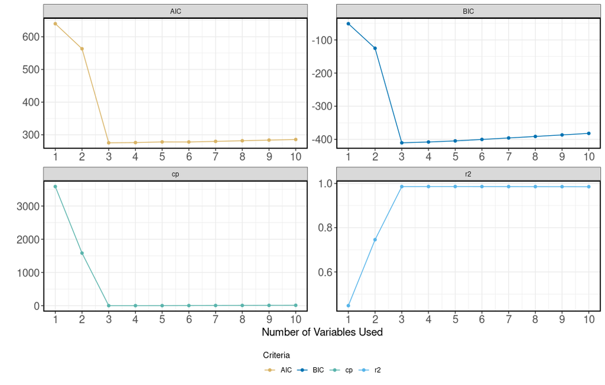

```r
data_model_selection %>%

    #Transform to long format
    gather(value_type, value, -id) %>%
    ggplot(aes(id, value, col = value_type)) +
    geom_line() +
    geom_point() +
    ylab('') +
    xlab('Number of Variables Used') +
    facet_wrap(~ value_type, scales = 'free') +
    theme_bw() +
    scale_x_continuous(breaks = 1:10) +
    # Change color
    scale_colour_manual(values = c("#d8b365", "#0072B2", "#5ab4ac",
                                   "#56B4E9")) +

    # Edit the legend
    theme(axis.text.y   = element_text(size = 14),
                # Legend position and Axis size
                legend.position = "bottom",
                axis.text.x   = element_text(size = 14),
                      axis.title.y  = element_text(size = 14),
                      axis.title.x  = element_text(size = 14),
                # Add borders to the plot
                      panel.border = element_rect(colour = "black", fill= NA,size = 1.3)) +

      # Edit legend name
      labs(colour = "Criteria") +

      #Edit legend
      guides(col = guide_legend(override.aes = list(fill=NA),nrow = 1,title.position = "top",))
```

**(c) Repeat (b), using forward selection. How does your answer compare to the results in (b)?**

```r
#https://rpubs.com/bgautijonsson/353795
#https://ashutoshtripathi.com/2019/06/10/what-is-stepaic-in-r/
```

```r
fit_forward <- regsubsets(y ~ poly(x, 10), data = data_from_linear_model,
                          nvmax = 10, method = "forward")
fit_summary_forward <- summary(fit_forward)

# Choose best model
data.frame(
  r2 = which.max(fit_summary_forward$adjr2),
  cp = which.min(fit_summary_forward$cp),
  BIC = which.min(fit_summary_forward$bic)
)
```

```
  r2 cp BIC
1  5  3   3
```

```r
fit_aic_forward <- stepAIC(lm(y ~ poly(x, 10)),direction =  "forward")
```

```
Start:  AIC=-0.05
y ~ poly(x, 10)
```

```r
summary(fit_aic_forward)
```

```
Call:
lm(formula = y ~ poly(x, 10))

Residuals:
     Min       1Q   Median       3Q      Max
-2.28294 -0.62459 -0.08981  0.50591  2.65617

Coefficients:
               Estimate Std. Error t value Pr(>|t|)
(Intercept)    11.10785    0.09493 117.006   <2e-16 ***
poly(x, 10)1  -52.43917    0.94934 -55.238   <2e-16 ***
poly(x, 10)2   42.51441    0.94934  44.783   <2e-16 ***
poly(x, 10)3  -37.79259    0.94934 -39.809   <2e-16 ***
poly(x, 10)4    1.02112    0.94934   1.076    0.285
poly(x, 10)5    0.02742    0.94934   0.029    0.977
poly(x, 10)6   -1.33085    0.94934  -1.402    0.164
poly(x, 10)7   -0.34381    0.94934  -0.362    0.718
poly(x, 10)8   -0.22058    0.94934  -0.232    0.817
poly(x, 10)9   -0.08383    0.94934  -0.088    0.930
poly(x, 10)10  -0.39258    0.94934  -0.414    0.680
---
Signif. codes:  0 '***' 0.001 '**' 0.01 '*' 0.05 '.' 0.1 ' ' 1

Residual standard error: 0.9493 on 89 degrees of freedom
Multiple R-squared:  0.9868,    Adjusted R-squared:  0.9853
F-statistic: 664.5 on 10 and 89 DF,  p-value: < 2.2e-16
```

**(d) Now fit a lasso model and use cross-validation to select the optimal values of λ. Create plots of the cross-validation error as a function f of λ. Report the resulting coefficient estimates, and discuss the results obtained**

```r
# Generate data

data_lasso <- data.frame(cbind(y,x,x^2,x^3,x^4,x^5,x^6,x^7,x^8,
                     x^9,x^10)) %>% clean_names()

x <- model.matrix(y ~. ,data_lasso)[, -1]
y <- data_lasso[,1]
```

```r
# split the samples into a training set and a test set

train <- sample(1:nrow(x),nrow(x) / 2)
test <- (-train)
y_test <- y[test]
```

```r
#cross-validation to select the optimal values of λ
cv_out <- cv.glmnet(x[train,] , y[train], alpha = 1)
```

```r
best_lamb <- cv_out$lambda.min
```

```r
# Perform lasso regression
lasso_mod <- glmnet(x[train,] , y[train] , alpha = 1)
lasso_pred <- predict(lasso_mod , s = best_lamb ,newx = x[test,])
```

```r
lasso_coef <- predict(lasso_mod, type = "coefficients",s = best_lamb)[1:11,]
lasso_coef
```

```
(Intercept)           x          v3          v4          v5          v6
  9.2157595   0.0000000   1.6485247  -1.4131634   0.0000000  -0.4545046
         v7          v8          v9         v10         v11
  0.0000000   0.0000000   0.0000000   0.0000000   0.0000000
```

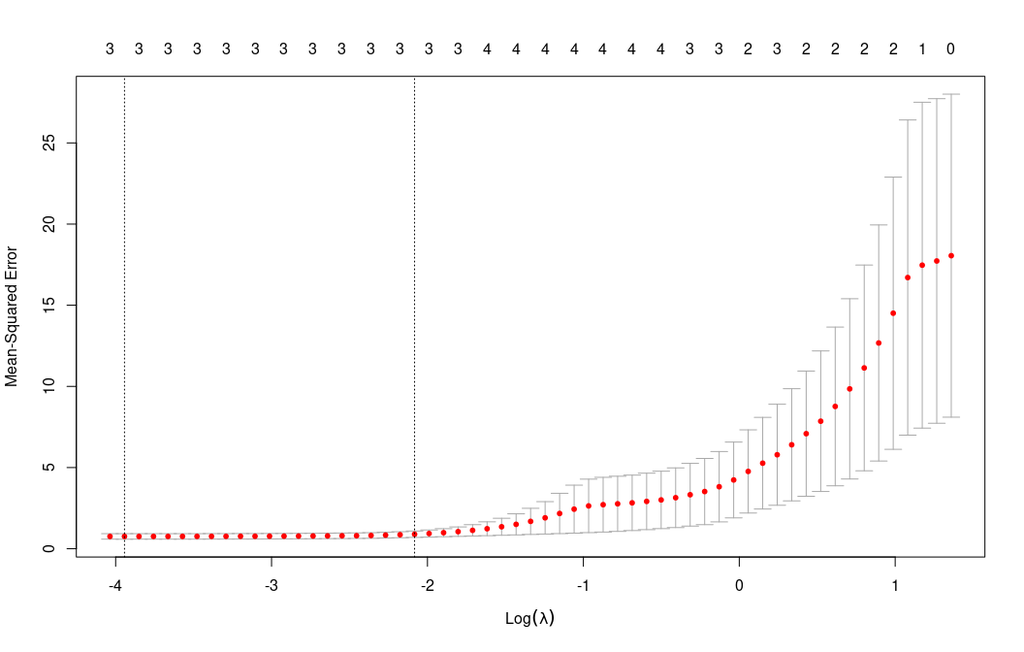

```r
# Create plots of the cross-validation error as a function f of λ
plot(cv_out)
```

# Exercise 2

```r
rm(x,y)
```

**The ability to get a good night’s sleep is correlated with many positive health outcomes. Use the NHANES data set from the NHANES package to predict *SleepHrsNight*. Check the R help document for detailed information about the data set.**

```r
# Load Data
data("NHANES")
data_p2 <- NHANES %>% clean_names()
```

**(b) Select your own predictors, and create plots or summary tables to explore the variables.**

```r
data_selected_var <-
  data_p2 %>%
  dplyr::select(sleep_hrs_night,gender,age,race1,education,marital_status,weight,poverty,diabetes,pulse) %>%
  na.omit()
```

**(a) First separate the data set at random into 75% training and 25% testing sets.**

```r
# Select X-Y for models
x_sleep <- model.matrix(sleep_hrs_night ~ . ,data_selected_var)[, -1]
y_sleep <- data_selected_var$sleep_hrs_night

# Sample data
index <-  sample(1:nrow(x_sleep), 0.75*nrow(x_sleep))

# Create the training data 75% training and 25% testing
train_data = x_sleep[index,]
(nrow(train_data)/6406)*100
```

```
[1] 74.99219
```

```r
# Create the test data
test_data = x_sleep[-index,]
(nrow(test_data)/6406)*100
```

```
[1] 25.00781
```

```r
#y_test_sleep <- y_sleep[test]
```

**(c) Build the following models using the training set with your predictors of choice:**

- Multiple linear regression

```r
m1 <- lm(y_sleep[train] ~ x_sleep[train,])
```

- Ridge regression

```r
# Model
m2_ridge <- glmnet(x_sleep[train, ], y_sleep[train] ,alpha = 0)

# Get best lambda
lambda_sleep_ridge <- cv.glmnet(x_sleep[train,], y_sleep[train], alpha = 0)

best_lamb_ridge <- lambda_sleep_ridge$lambda.min
```

- LASSO regression

```r
# Model
m3_lasso <- glmnet(x_sleep[train , ], y_sleep[train] ,alpha = 1)


# Get best lambda
lambda_sleep_lasso <- cv.glmnet(x_sleep[train,], y_sleep[train], alpha = 1)

best_lamb_lasso <- lambda_sleep_lasso$lambda.min
```

**(d) Compare the effectiveness of each model on training vs. testing data.**

- Linear regression MSE

```r
linear_prediction <- predict(m1,newx = x_sleep[test_data, ])


y_sleep_test <- y_sleep[test_data]
mean((linear_prediction - y_sleep_test)^2)
```

```
[1] 4.610984
```

- Ridge MSE

```r
ridge_pred <- predict(m2_ridge , s = best_lamb_ridge, newx = x_sleep[test_data,])
mean((ridge_pred - y_test)^2)
```

```
[1] 134.5172
```

- Lasso MSE

```r
lasso_pred <- predict(m3_lasso , s = best_lamb_lasso, newx = x_sleep[test_data,])
mean((lasso_pred - y_test)^2)
```

```
[1] 134.7703
```

**(e) Choose one best model and interpret the results. What have you learned about people’s sleeping quality?**

Based on the MSE I chose the Multiple linear regression model because it has the lowest MSE(~5)

```r
model <- lm(sleep_hrs_night~ .,  data = data_selected_var )
```

```r
summary(model)
```

```
Call:
lm(formula = sleep_hrs_night ~ ., data = data_selected_var)

Residuals:
    Min      1Q  Median      3Q     Max
-5.1784 -0.8510  0.0364  0.9724  5.3846

Coefficients:
                             Estimate Std. Error t value Pr(>|t|)
(Intercept)                 6.2330174  0.1814760  34.346  < 2e-16 ***
gendermale                 -0.1542632  0.0360749  -4.276 1.93e-05 ***
age                         0.0039484  0.0012562   3.143  0.00168 **
race1Hispanic               0.1995249  0.0872465   2.287  0.02223 *
race1Mexican                0.4125553  0.0810321   5.091 3.66e-07 ***
race1White                  0.3429789  0.0562556   6.097 1.15e-09 ***
race1Other                  0.2207623  0.0824077   2.679  0.00741 **
education9 - 11th Grade    -0.0549210  0.0875353  -0.627  0.53041
educationHigh School       -0.0379936  0.0838051  -0.453  0.65031
educationSome College       0.0494718  0.0830878   0.595  0.55159
educationCollege Grad       0.1255372  0.0866436   1.449  0.14742
marital_statusLivePartner   0.1166145  0.0816769   1.428  0.15341
marital_statusMarried       0.2213547  0.0581023   3.810  0.00014 ***
marital_statusNeverMarried  0.2946622  0.0686746   4.291 1.81e-05 ***
marital_statusSeparated    -0.0585239  0.1194170  -0.490  0.62409
marital_statusWidowed       0.2127429  0.0889478   2.392  0.01680 *
weight                     -0.0023359  0.0008498  -2.749  0.00600 **
poverty                     0.0294824  0.0120237   2.452  0.01423 *
diabetesYes                -0.0072460  0.0579838  -0.125  0.90055
pulse                       0.0017409  0.0014604   1.192  0.23329
---
Signif. codes:  0 '***' 0.001 '**' 0.01 '*' 0.05 '.' 0.1 ' ' 1

Residual standard error: 1.319 on 6386 degrees of freedom
Multiple R-squared:  0.02815,   Adjusted R-squared:  0.02526
F-statistic: 9.735 on 19 and 6386 DF,  p-value: < 2.2e-16
```